# Reproducible Research Week 2 Course Project 1

Lidwien van de Wijngaert

3/13/2020

### Load libraries

```r
library(stringr)
library(lubridate)
```

```r
library(ggplot2)
library(scales)
library(dplyr)
# library(Hmisc)
```

### 1. Code for reading in the dataset and/or processing the data

Show any code that is needed to

Load the data (i.e. read.csv()read.csv())

```r
    if(!file.exists('activity.csv')){
        unzip('activity.zip')
    }
    activityData <- as.data.frame(read.csv('activity.csv'))
```

Process/transform the data (if necessary) into a format suitable for your analysis

Steps to take - Because interval is a integer, I first convert it to a string - Subset the two last characters - Subset the hours - Merge into time

```r
# Compute minutes
activityData$minutes <- str_sub(as.character(activityData$interval), -2, -1)
activityData$minutes <- as.numeric(activityData$minutes)

# Compute hours
activityData$hour <- (activityData$interval - activityData$minutes)/100
activityData$hour <- as.numeric(activityData$hour)

# Merge hour and minutes into time
activityData$time <- paste(activityData$hour, activityData$minutes, "00", sep=":")

# Combine date and time into datetime
activityData$datetime <- paste(activityData$date, activityData$time)
activityData$datetime <- ymd_hms(activityData$datetime)
```

### 2. Histogram of the total number of steps taken each day

For this part of the assignment, you can ignore the missing values in the dataset.

Calculate the total number of steps taken per day

```r
# Sum of steps per day
stepsPerDay1 <- as_tibble(aggregate(x=activityData$steps, by=list(date=activityData$date), FUN=sum))
stepsPerDay1 <- rename(stepsPerDay1, totalsteps=x)

stepsPerDay2 <- as_tibble(tapply(activityData$steps, activityData$date, sum, na.rm=TRUE))
stepsPerDay2 <- rename(stepsPerDay2, totalsteps=value)
```

Make a histogram of the total number of steps taken each day

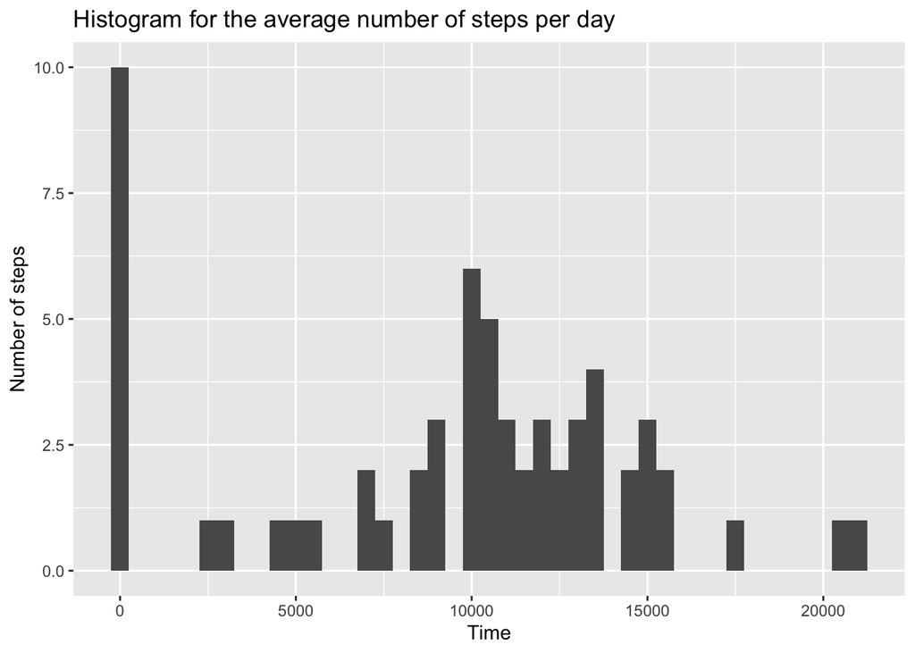

```r
# Make histogram
ggplot(data=stepsPerDay2, aes(stepsPerDay2$totalsteps)) +
  geom_histogram(binwidth=500) +
    labs(title="Histogram for the average number of steps per day", x="Time", y="Number of steps")
```

### 3. Mean and median number of steps taken each day

What is the average daily activity pattern?

Calculate and report the mean and median of the total number of steps taken per day

```r
# Mean of the number of steps over all days
round(mean(stepsPerDay1$totalsteps, na.rm=TRUE), 0)
```

```
## [1] 10766
```

```r
round(mean(stepsPerDay2$totalsteps), 0)
```

```
## [1] 9354
```

```r
# Median of the number of steps over alle days
round(median(stepsPerDay1$totalsteps, na.rm=TRUE), 0)
```

```
## [1] 10765
```

```r
round(median(stepsPerDay2$totalsteps), 0)
```

```
## [1] 10395
```

```r
# The difference is caused by the fact that NA is not taken into account in stepsPerDay2. NA counts as zero which reduces the average.
```

The average daily activity pattern shows that this user takes approximately tenthousand steps per day.

### 4. Time series plot of the average number of steps taken

Make a time series plot (i.e. type = “l”type=“l”) of the 5-minute interval (x-axis) and the average number of steps taken, averaged across all days (y-axis)

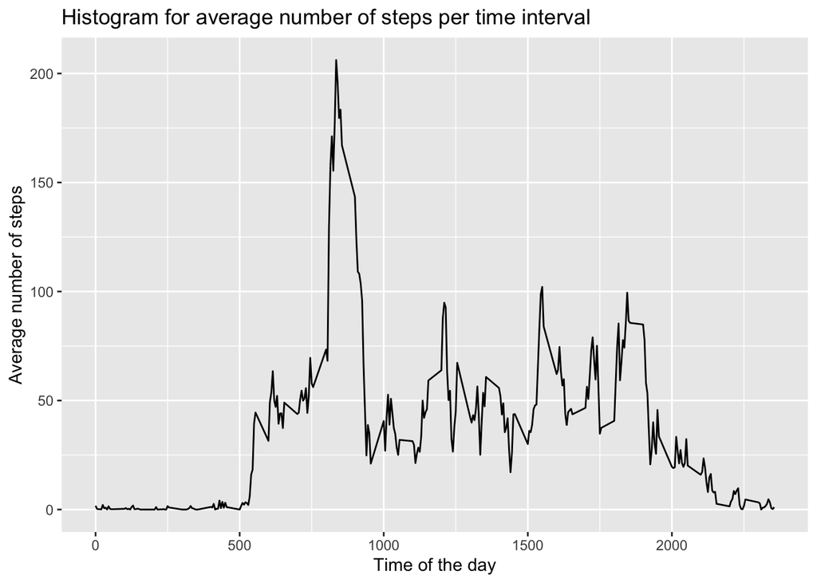

```r
# Compute the average per time interval
stepsPerInterval <- as_tibble(aggregate(x=activityData$steps, by=list(interval=activityData$interval), FUN=mean, na.rm=TRUE))
stepsPerInterval <- rename(stepsPerInterval, averagesteps=x)

# Make histogram
ggplot(data=stepsPerInterval, binwidth=50, aes(stepsPerInterval$interval, stepsPerInterval$averagesteps)) +
  geom_line()+
    labs(title="Histogram for average number of steps per time interval", x="Time of the day", y="Average number of steps")
```

This guy sleeps at night and walks to work.

### 5. The 5-minute interval that, on average, contains the maximum number of steps

Which 5-minute interval, on average across all the days in the dataset, contains the maximum number of steps?

```r
# Now use time (instead of interval)
stepsPerTime <- as_tibble(aggregate(x=activityData$steps, by=list(time=activityData$time), FUN=mean, na.rm=TRUE))
stepsPerTime <- rename(stepsPerTime, averagesteps=x)

# Select maximum number of average number of step in specific time interval
m <- max(stepsPerTime$averagesteps)
max <- subset(stepsPerTime, stepsPerTime$averagesteps == m)
print(round(m, 0))
```

```
## [1] 206
```

```r
print(max$time)
```

```
## [1] "8:35:00"
```

### 6. Code to describe and show a strategy for imputing missing data

Imputing missing values

Note that there are a number of days/intervals where there are missing values (coded as NANA).

The presence of missing days may introduce bias into some calculations or summaries of the data.

Calculate and report the total number of missing values in the dataset (i.e. the total number of rows with NANAs)

```r
print(paste("The number of missing (NA) values is:", sum(is.na(activityData$steps))))
```

```
## [1] "The number of missing (NA) values is: 2304"
```

Devise a strategy for filling in all of the missing values in the dataset. The strategy does not need to be sophisticated. For example, you could use the mean/median for that day, or the mean for that 5-minute interval, etc.

Create a new dataset that is equal to the original dataset but with the missing data filled in.

```r
activityDataImputed <- activityData
activityDataImputed$steps[is.na(activityDataImputed$steps)] <- round(mean(activityDataImputed$steps, na.rm = TRUE))
```